# Instructions

Nathan Riojas, Corey Monreal-Jackson, Ryan Billa

September 30, 2015

#### Steps used to create this project

##### 1. Using GitHub, create a Repo

##### 2. Clone the Repository into the Data Visualization Folder (Or the folder you wish)

##### 3. Create R Studio Folders for all the project development (folder descriptions below)

##### 4. Locate a CSV data file and save it to the data folder

##### 5. Modify the R_ETL.R given and run the code to get the code to develop a SQL table

##### 6. Using Oracle SQL Developer, paste the code output from the R_ETL.R script to create a table

##### 7. After the table is created, import the data from the CSV reformattted file to the table

##### 8. Use a query statement similar to the TitanicAnalysis.R file (used in the last project) to build a data frame with the CSV data from Oracle

##### 9. Build 3 different workflows using R code and %>%. These will become new dataframes.

##### 10. Generate unique plots from the workflow dataframes

##### 11. Call these files in a .Rmd file using the R markdown command “source” and press Knit HTML to view the data/plots. (Code seen below) Note: Tables will also be generated to show the what the workflows created.

#### Folders Needed

##### 00 Doc: Holds the .Rmd and .html files containing these instructions and project output. Also holds RPROFILE to load all required packages.

##### 01 Data: Generates the code to create the table in Oracle. Gathers the data from the database for and puts it into data frames

##### 02 Data Wrangling: Contains the .R files that use create workflows from the data frame create from the CSV data put into Oracle.

##### 03 Visualization: Contains the .R files that use ggplot to generate graph our graphs

#### R markdown code

```
#setwd("C:/Users/Nathan R/Documents/DataVisualization/Project 2/01 Data")

#file_path <- "Fortune 500 Companies.csv"

#df <- read.csv(file_path, stringsAsFactors = FALSE)

# Replace "." (i.e., period) with "_" in the column names.
#names(df) <- gsub("\\.+", "_", names(df))

#str(df) # Uncomment this and  run just the lines to here to get column types to use for getting the list of measures.

#measures <- c("Year", "Rank")
#measures <- NA # Do this if there are no measures.

# Get rid of special characters in each column.
# Google ASCII Table to understand the following:
#for(n in names(df)) {
#  df[n] <- data.frame(lapply(df[n], gsub, pattern="[^ -~]",replacement= ""))
#}

# dimensions <- setdiff(names(df), measures)
# if( length(measures) > 1 || ! is.na(dimensions)) {
#   for(d in dimensions) {
#     # Get rid of " and ' in dimensions.
#     df[d] <- data.frame(lapply(df[d], gsub, pattern="[\"']",replacement= ""))
#     # Change & to and in dimensions.
#     df[d] <- data.frame(lapply(df[d], gsub, pattern="&",replacement= " and "))
#     # Change : to ; in dimensions.
#     df[d] <- data.frame(lapply(df[d], gsub, pattern=":",replacement= ";"))
#   }
# }
#
# library(lubridate)
# Fix date columns, this needs to be done by hand because | needs to be correct.
#                                                        \_/


# The following is an example of dealing with special cases like making state abbreviations be all upper case.
# df["State"] <- data.frame(lapply(df["State"], toupper))

```

[output cut: 9 more lines]

```
# tableName <- gsub(" +", "_", gsub("[^A-z, 0-9, ]", "", gsub(".csv", "", file_path)))
# sql <- paste("CREATE TABLE", tableName, "(\n-- Change table_name to the table name you want.\n")
# if( length(measures) > 1 || ! is.na(dimensions)) {
#   for(d in dimensions) {
#     sql <- paste(sql, paste(d, "varchar2(4000),\n"))
#   }
# }
# if( length(measures) > 1 || ! is.na(measures)) {
#   for(m in measures) {
#     if(m != tail(measures, n=1)) sql <- paste(sql, paste(m, "number(38,4),\n"))
#     else sql <- paste(sql, paste(m, "number(38,4)\n"))
#   }
# }
# sql <- paste(sql, ");")
# cat(sql)
```

```r
source("../00 Doc/RPROFILE.R", echo = TRUE)
```

```
##
## > require("ggplot2")
```

```
##
## > require("ggthemes")
```

```
##
## > require("gplots")
```

```
##
## > require("grid")
```

```
##
## > require("RCurl")
```

```
##
## > require("reshape2")
```

```
##
## > require("tableplot")
```

```
##
## > require("tidyr")
```

```
##
## > require("dplyr")
```

```
##
## > require("jsonlite")
```

```
##
## > require("extrafont")
```

```
## Registering fonts with R
```

```
##
## > require("lubridate")
```

```r
source("../01 Data/Fortune500.R", echo = TRUE)
source("../01 Data/Fortune 500 Analysis.R", echo = TRUE)
```

```
##
## > require("jsonlite")
##
## > require("RCurl")
##
## > require("ggplot2")
##
## > df <- data.frame(fromJSON(getURL(URLencode("129.152.144.84:5001/rest/native/?query=\"select * from fortune_500_companies\""),
## +     httpheader = c( .... [TRUNCATED]
##
## > summary(df)
##                 COMPANY            REVENUE_IN_MILLIONS_
##  CBS                :   61   85              :   10
##  OfficeMax          :   59   86.1999969482422:   10
##  3M                 :   55   90              :   10
##  Abbott Laboratories:   55   145.399993896484:    9
##  Alcoa              :   55   197.5           :    9
##  Altria Group       :   55   76.4000015258789:    9
##  (Other)            :29160   (Other)         :29443
##        PROFIT_IN_MILLIONS_      YEAR           RANK
##  N.A.            :  369    Min.   :1955   Min.   :   1.0
##  4               :   75    1st Qu.:1969   1st Qu.: 135.0
##  3               :   71    Median :1984   Median : 269.0
##  5.69999980926514:   67    Mean   :1984   Mean   : 284.4
##  6               :   67    3rd Qu.:1999   3rd Qu.: 403.0
##  3.09999990463257:   66    Max.   :2009   Max.   :1000.0
##  (Other)         :28785
##
## > head(df)
##            COMPANY REVENUE_IN_MILLIONS_ PROFIT_IN_MILLIONS_ YEAR RANK
## 1   General Motors               9823.5                 806 1955    1
## 2      Exxon Mobil     5661.39990234375    584.799987792969 1955    2
## 3       U.S. Steel     3250.39990234375    195.399993896484 1955    3
## 4 General Electric     2959.10009765625    212.600006103516 1955    4
## 5           Esmark     2510.80004882812    19.1000003814697 1955    5
## 6         Chrysler     2071.60009765625                18.5 1955    6
```

```r
source("../02 Data Wrangling/Fortune500 Wrangling.R", echo = TRUE)
```

```
##
## > Solo_1995 <- df %>% select(COMPANY, YEAR, PROFIT_IN_MILLIONS_,
## +     REVENUE_IN_MILLIONS_) %>% filter(YEAR == 1955) %>% mutate(Rev = as.numeric(as. .... [TRUNCATED]
##
## > Summarized <- df %>% group_by(YEAR, RANK, REVENUE_IN_MILLIONS_) %>%
## +     summarise(Expenses = sum(-as.numeric(as.character(PROFIT_IN_MILLIONS_)),  .... [TRUNCATED]
##
## > Top_5 <- df %>% select(COMPANY, REVENUE_IN_MILLIONS_,
## +     PROFIT_IN_MILLIONS_, YEAR, RANK) %>% filter(YEAR %in% c(1955:2000),
## +     COMPANY %in% .... [TRUNCATED]
##
## > tbl_df(Solo_1995)
## Source: local data frame [24 x 7]
##
##                       COMPANY  YEAR PROFIT_IN_MILLIONS_
##                        (fctr) (int)              (fctr)
## 1              General Motors  1955                 806
## 2                 Exxon Mobil  1955    584.799987792969
## 3                      DuPont  1955    344.399993896484
## 4                         CBS  1955    84.5999984741211
## 5       AT and T Technologies  1955    55.7999992370605
## 6                       Kraft  1955    37.4000015258789
## 7  Goodyear Tire  and  Rubber  1955    48.0999984741211
## 8                      Boeing  1955                  37
## 9                Sinclair Oil  1955    91.5999984741211
## 10     Navistar International  1955    36.2999992370605
## ..                        ...   ...                 ...
## Variables not shown: REVENUE_IN_MILLIONS_ (fctr), Rev (dbl), prof_percent
##   (dbl), Ninety_Percentile (lgl)
##
## > tbl_df(Summarized)
## Source: local data frame [52 x 4]
##
##     YEAR  RANK REVENUE_IN_MILLIONS_ Expenses
##    (int) (int)               (fctr)    (dbl)
## 1   1975     1       42061.30078125  38919.1
## 2   1975    10      11154.400390625  10703.3
## 3   1976     1       44864.80078125  42361.8
## 4   1976    10     11699.2998046875  11958.8
## 5   1977     1       48630.80078125  45989.8
```

[output cut: 8 more lines]

```
## Source: local data frame [168 x 5]
##
##           COMPANY REVENUE_IN_MILLIONS_ PROFIT_IN_MILLIONS_  YEAR  RANK
##            (fctr)               (fctr)              (fctr) (int) (int)
## 1  General Motors               9823.5                 806  1955     1
## 2     Exxon Mobil     5661.39990234375    584.799987792969  1955     2
## 3          Esmark     2510.80004882812    19.1000003814697  1955     5
## 4          DuPont     1687.69995117188    344.399993896484  1955    10
## 5  General Motors     12443.2998046875              1189.5  1956     1
## 6     Exxon Mobil     6272.39990234375    709.299987792969  1956     2
## 7          Esmark     2404.10009765625    22.8999996185303  1956     7
## 8          DuPont     1909.19995117188    431.600006103516  1956    10
## 9  General Motors      10796.400390625    847.400024414062  1957     1
## 10    Exxon Mobil     7126.89990234375               808.5  1957     2
## ..            ...                  ...                 ...   ...   ...
```

```r
source("../03 Visualizations/Companies Visualization.R", echo = TRUE)
```

```
##
## > require(extrafont)
##
## > ggplot() + coord_cartesian() + scale_x_discrete() +
## +     scale_y_continuous() + labs(title = "Revenue vs Company in 1955") +
## +     theme(axis.tex .... [TRUNCATED]
```

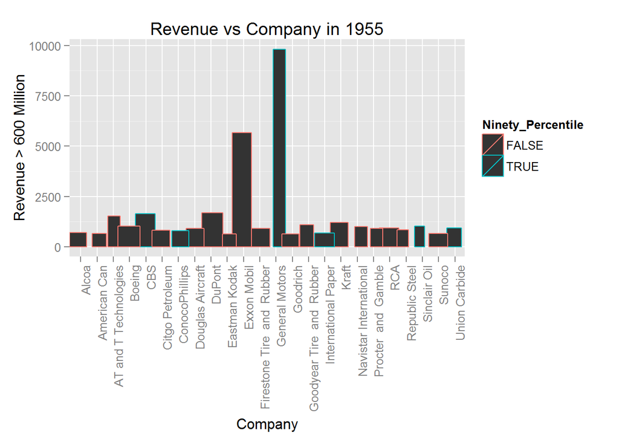

```
##
## > ggplot() + coord_cartesian() + scale_x_discrete() +
## +     scale_y_continuous() + labs(title = "Top 5 Companies in 1955 Over Time") +
## +     theme(a .... [TRUNCATED]
```

[figure not shown]

```
##
## > ggplot() + coord_cartesian() + scale_x_discrete() +
## +     scale_y_continuous() + labs(title = "Expenditure Difference Between Fortune 500 Rank 1 an ..." ... [TRUNCATED]
```

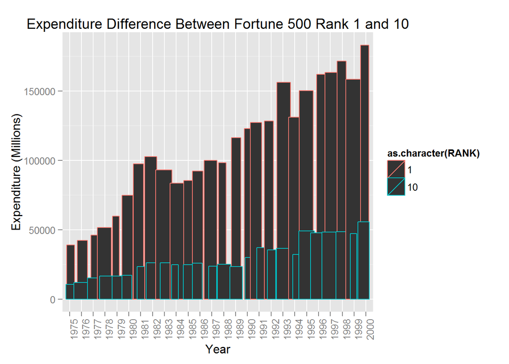